# Figures for Halobacterium CNV paper

Keely Dulmage

July 7, 2017

```r
library(DNAcopy)
library(foreach)
library(dplyr)
#source()
```

## Introduction

The following code generates figures for the Halobacterium CNV manuscript. This code uses the CNV package DNAcopy to analyze both gene expression and ChIP microarrays.

```r
## All gene expression microarrays (numbers are standardized z scores)
all_data <- read.delim(file = "data/Gene_expression_Master.txt", row.names = 1)
## Empty array to be filled for the generation of segment maps
rarray <- read.delim(file = "data/rarray_allloci.txt")
```

# Fig 12: GE microarray data analysis

```r
write.csv(segsmot$output, file = "results/segmented_GE_arrays.csv")
```

[output not shown]

```r
load(file = "data/segmented_GE_arrays.Rdata")
```

### Figure 12A rainbow plots

Generate maps of segments at different fragment size thresholds

```r
t1f100.copy <- copymap4(ref_array = rarray, seg_array = segsmot$output, threshold = 1, f.size = 100)
t1f1k.copy <- copymap4(ref_array = rarray, seg_array = segsmot$output, threshold = 1, f.size = 1000)
t1f5k.copy <- copymap4(ref_array = rarray, seg_array = segsmot$output, threshold = 1, f.size = 5000)
t1f10k.copy <- copymap4(ref_array = rarray, seg_array = segsmot$output, threshold = 1, f.size = 10000)
t1f20k.copy <- copymap4(ref_array = rarray, seg_array = segsmot$output, threshold = 1, f.size = 20000)
t1f50k.copy <- copymap4(ref_array = rarray, seg_array = segsmot$output, threshold = 1, f.size = 50000)
t1f100k.copy <- copymap4(ref_array = rarray, seg_array = segsmot$output, threshold = 1, f.size = 100000)
```

Split by chromosome

```r
t1f100.split <- split2(t1f100.copy)
t1f1k.split <- split2(t1f1k.copy)
t1f5k.split <- split2(t1f5k.copy)
t1f10k.split <- split2(t1f10k.copy)
t1f20k.split <- split2(t1f20k.copy)
t1f50k.split <- split2(t1f50k.copy)
t1f100k.split <- split2(t1f100k.copy)
```

Chromosome by gene expression segment size frequency

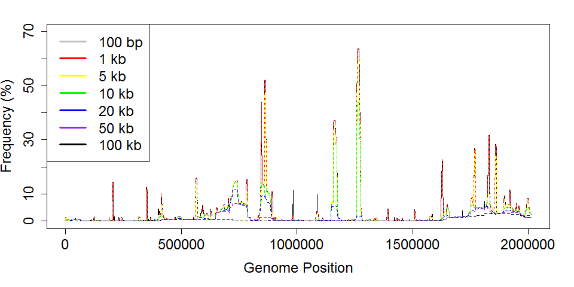

pNRC100 by gene expression segment size frequency

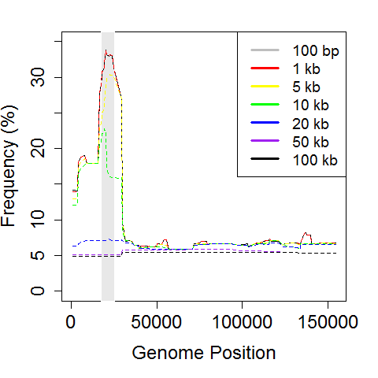

pNRC200 by gene expression segment size frequency

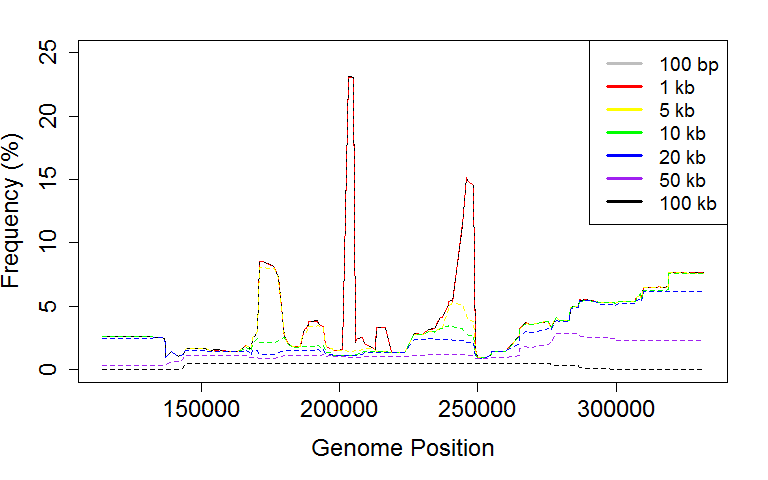

### Figure 12B

pNRC100

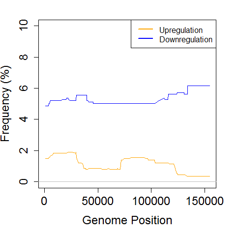

pNRC200

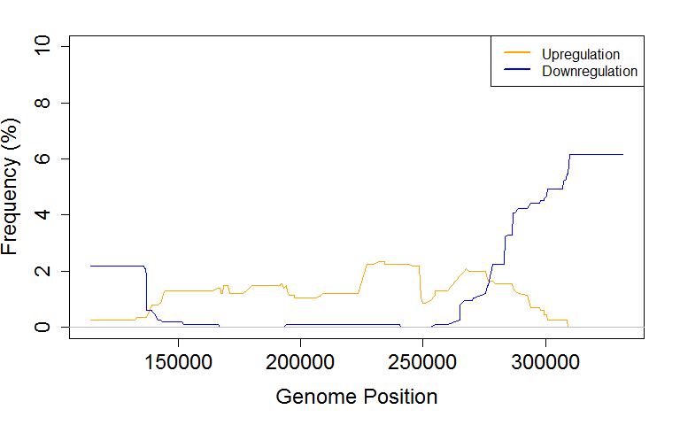

# Fig 13: ChIP microarray data analysis

Samples were parsed, median-centered, scaled, and segmented in independent batches before combining. The following code takes segmented chip array data and creates composite maps. Original data is available upon request.

```r
## Read in segmented ChIP data
load(file = "data/all.med2.Rdata")
## Read in Trmb file 12 for example segmentation output
load(file = "data/trmb12.Rdata")
```

## Figure 13A

Example segmentation output, Trmb12

```r
trmb12.cna <- CNA(genomdat = as.numeric(trmb12.m$Scaled), chrom = trmb12.m$Chr, maploc = as.numeric(trmb12.m$Position), sampleid = "Trmb 12")
trmb12.smooth <- smooth.CNA(trmb12.cna)
trmb12.segsmot <- segment(trmb12.smooth)
```

```
Analyzing: Trmb.12
```

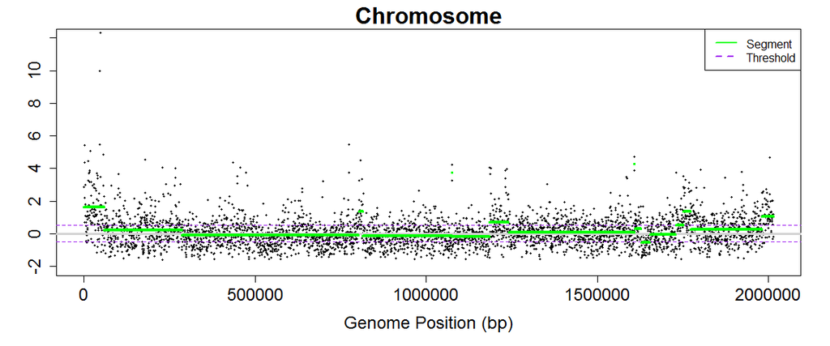

## Figure 13B

Frequency map of all ChIP CNVs, split by depletion/amplification events

```r
# Generate copymap
crarray <- read.delim(file = "~/Desktop/CNV manuscript info/rarray_2400_moved_probes.txt")
crarray <- droplevels(crarray[crarray$Chr == "Chr",])
chip.copy <- copymap4(ref_array = crarray, seg_array = test, threshold = 0.5, f.size = 5000)
chip.split <- split2(chip.copy)[[1]] %>% dplyr::arrange(Start)
```

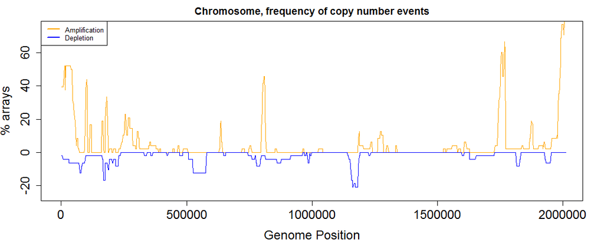

## Figure 13C

Frequency map of all ChIP CNVs, with IS elements marked

```r
## read in ISH table
ish <- read.delim(file = "data/20170703_ISfinder_ISH_elements.txt")
## read in peaks vector
peaks <-load("data/Chip_peak_regions.Rdata")
```

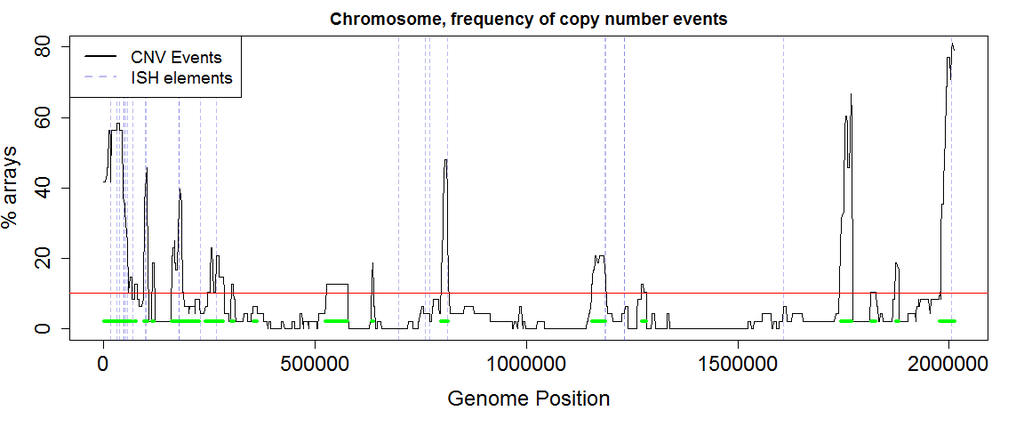

## Figure 13D

IS elements are associated with CNV regions at higher rate than expected by chance: bootstrapping results

```r
set.seed(8876)
ISboot <- function(IS_number, peaks){
    boot=c()
    for(i in 1:10000){
    ISlist= sample(1:2014239,IS_number)
    boot[i]= length(which(ISlist %in% peaks))
    }
    boot
}
## of IS elements in chr peaks (note: IS table is for chromosome only)
is.n <- length(ish$Start[ish$Start %in% peaks7])
ish.boot <- ISboot(is.n, peaks7)
```

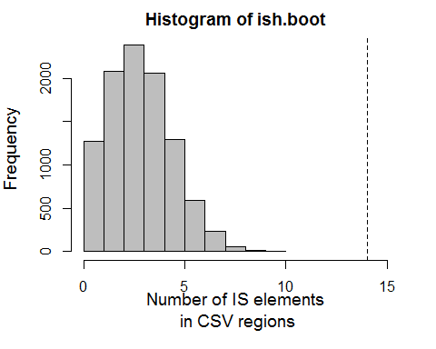